# Linear Regressions

We’ll start with all of the block groups and just a bivariate relationship.

So here is violent crime (the index) and the raw mean NDVI values for block groups.
$$Crime_i=\alpha+\beta NDVI_i + \epsilon_i$$

```r
mod_1 <- lm(CRMCYPERC ~ ndvi_mean_cbg_adj, data = df)
tidy(mod_1)
```

| term | estimate | std.error | statistic | p.value |
| --- | --- | --- | --- | --- |
| (Intercept) | 177.631156 | 1.8848548 | 94.241294 | 0.000000000 |
| ndvi_mean_cbg_adj | 1.370242 | 0.4345133 | 3.153509 | 0.001613969 |

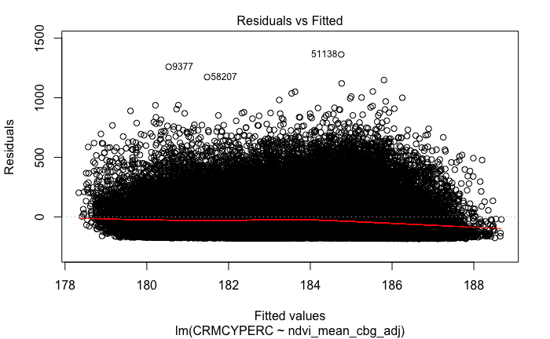

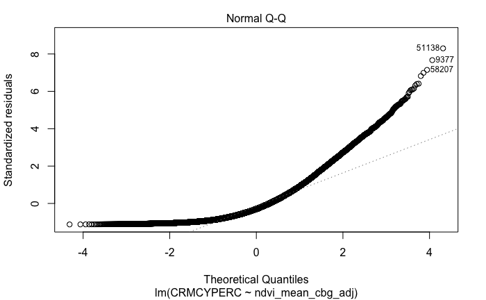

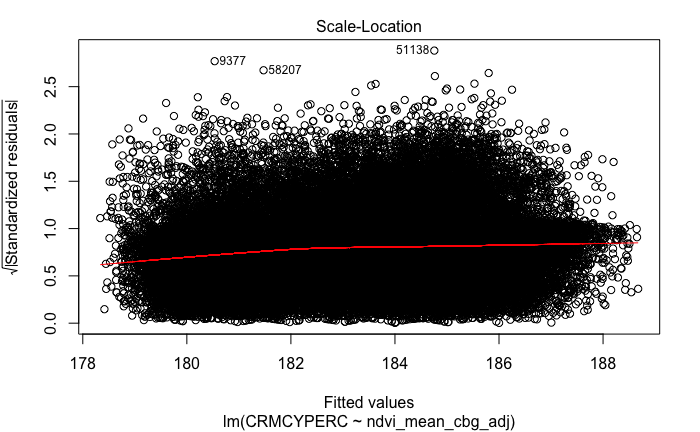

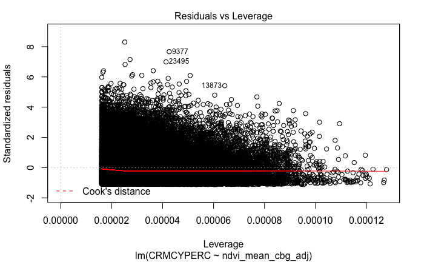

```r
plot(mod_1)
```

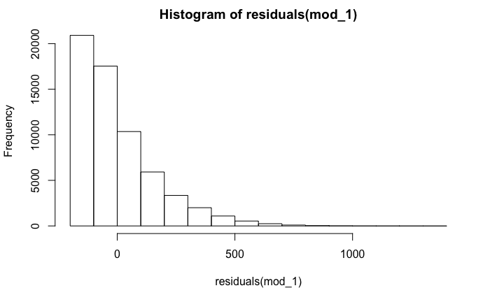

```r
hist(residuals(mod_1))
```

Now add the level 1 covariates and see what happens.

$$Crime_i = \alpha + \beta NDVI_i + \beta_{...} L1\ covariates_i + \epsilon_i$$

```r
mod_2 <- lm(CRMCYPERC ~ ndvi_mean_cbg_adj + MedHHinc_000 + disad + divindex + log_popden_cbg, data = df)
tidy(mod_2)
```

| term | estimate | std.error | statistic | p.value |
| --- | --- | --- | --- | --- |
| (Intercept) | 321.2321363 | 5.48920233 | 58.5207316 | 0.000000e+00 |
| ndvi_mean_cbg_adj | 0.2290418 | 0.40069087 | 0.5716171 | 5.675836e-01 |
| MedHHinc_000 | -0.5053379 | 0.02182931 | -23.1495159 | 4.886636e-118 |
| disad | 117.5306994 | 0.92409176 | 127.1850960 | 0.000000e+00 |
| divindex | -58.9247513 | 2.92588762 | -20.1391027 | 6.684775e-90 |
| log_popden_cbg | -12.5712865 | 0.53601605 | -23.4531903 | 4.345786e-121 |

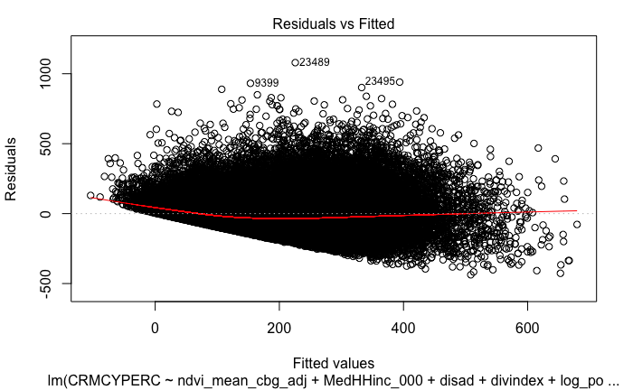

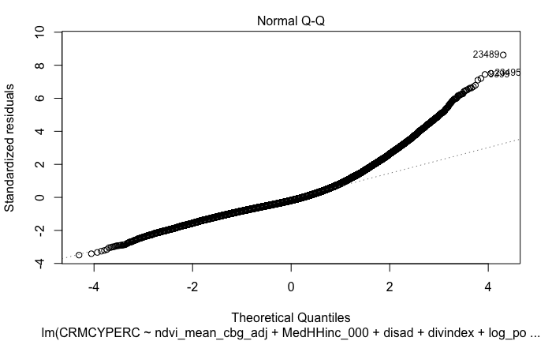

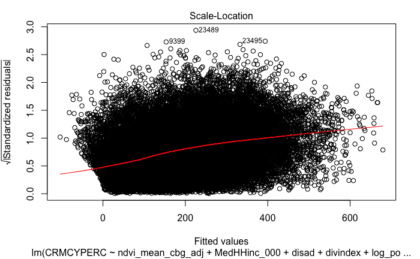

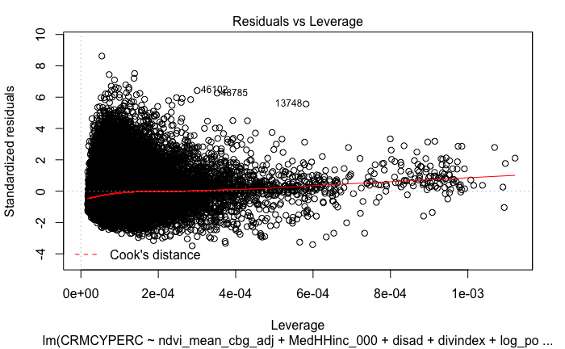

```r
plot(mod_2)
```

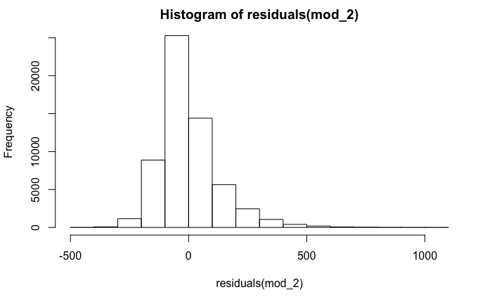

```r
hist(residuals(mod_2))
```

Now add the city level variables to see how linear regression does, though it is not addressing our questions.

$$Crime_i = \alpha + \beta NDVI_i + \beta_{...} L1\ covariates_i + \beta_{...} L2\ covariates_i +\epsilon_i$$

```r
mod_3 <- lm(CRMCYPERC ~ ndvi_mean_cbg_adj + MedHHinc_000 + disad + divindex + log_popden_cbg + factor(clust4) + Pop2015 + rate_violentcrime + PCgdp15 + PerCapitaOfficers1000, data = df)
tidy(mod_3)
```

| term | estimate | std.error | statistic | p.value |
| --- | --- | --- | --- | --- |
| (Intercept) | 3.232132e+02 | 5.168235e+00 | 62.538401 | 0.000000e+00 |
| ndvi_mean_cbg_adj | -2.253781e+01 | 4.480565e-01 | -50.301270 | 0.000000e+00 |
| MedHHinc_000 | -3.432729e-01 | 1.918863e-02 | -17.889388 | 2.194280e-71 |
| disad | 9.836058e+01 | 7.915743e-01 | 124.259439 | 0.000000e+00 |
| divindex | -2.797432e+01 | 2.504860e+00 | -11.168019 | 6.246962e-29 |
| log_popden_cbg | -2.959823e+01 | 5.618683e-01 | -52.678231 | 0.000000e+00 |
| factor(clust4)cool_wet | 6.911063e+01 | 1.715463e+00 | 40.286863 | 0.000000e+00 |
| factor(clust4)warm_wet | 4.692534e+01 | 1.682305e+00 | 27.893487 | 3.987244e-170 |
| factor(clust4)cool_dry | 5.617673e+01 | 1.726182e+00 | 32.543927 | 2.685792e-230 |
| Pop2015 | -1.049133e-06 | 3.248967e-07 | -3.229127 | 1.242358e-03 |

[output cut: 3 more lines]

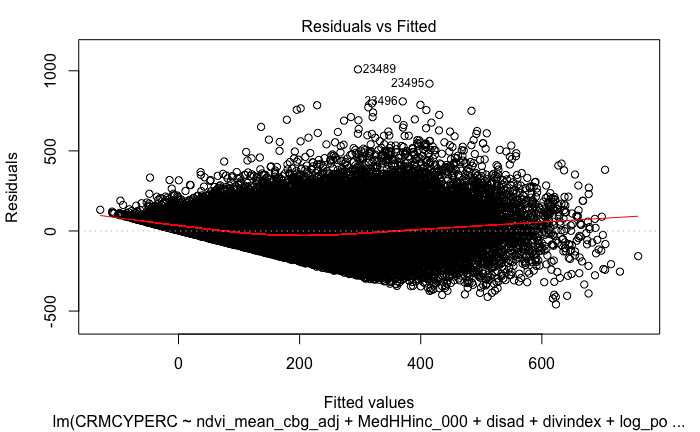

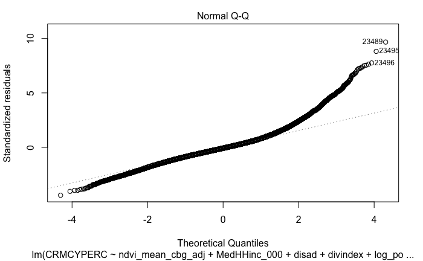

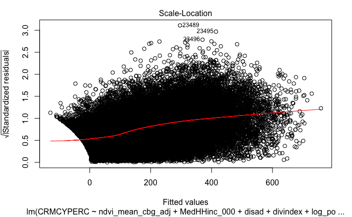

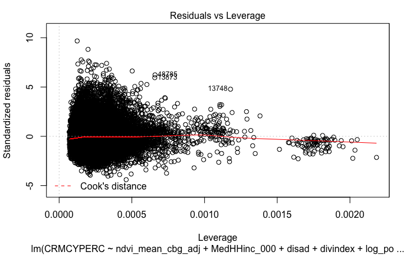

```r
plot(mod_3)
```

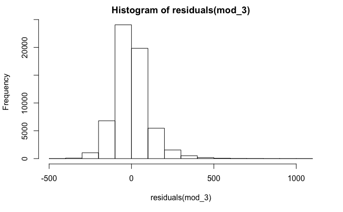

```r
hist(residuals(mod_3))
```

```r
screenreg(list(mod_1, mod_2, mod_3))
```

```
================================================================
                        Model 1       Model 2       Model 3
----------------------------------------------------------------
(Intercept)               177.63 ***    321.23 ***    323.21 ***
                           (1.88)        (5.49)        (5.17)
ndvi_mean_cbg_adj           1.37 **       0.23        -22.54 ***
                           (0.43)        (0.40)        (0.45)
MedHHinc_000                             -0.51 ***     -0.34 ***
                                         (0.02)        (0.02)
disad                                   117.53 ***     98.36 ***
                                         (0.92)        (0.79)
divindex                                -58.92 ***    -27.97 ***
                                         (2.93)        (2.50)
log_popden_cbg                          -12.57 ***    -29.60 ***
                                         (0.54)        (0.56)
factor(clust4)cool_wet                                 69.11 ***
                                                       (1.72)
factor(clust4)warm_wet                                 46.93 ***
                                                       (1.68)
factor(clust4)cool_dry                                 56.18 ***
                                                       (1.73)
Pop2015                                                -0.00 **
                                                       (0.00)
rate_violentcrime                                      18.16 ***
                                                       (0.15)
PCgdp15                                                 0.00 ***
                                                       (0.00)
PerCapitaOfficers1000                                  -5.08 ***
                                                       (0.69)
----------------------------------------------------------------
R^2                         0.00          0.40          0.58
Adj. R^2                    0.00          0.40          0.58
Num. obs.               62086         59647         59647
RMSE                      164.21        125.18        104.31
================================================================
*** p < 0.001, ** p < 0.01, * p < 0.05
```

Some things to consider:

- the crime index is a non-negative integer, might point to using a gamma distribution in GLS
- Should plot the explanatory variables against the residuals to see if there is a clue about the heterogenaity on residuals (can see that the higher the fitted value the greater the variance)